# Loan Data from Prosper

*by Bruno de Assis Pereira*

*February 05, 2018*

In this project, I am going to present an **Exploratory Data Analysis** over a dataset that contains informations about **Loans**. This dataset belongs to [Prosper](https://www.prosper.com/) and it contains *113,937 loans* with *81 variables* on each loan.

The **Loan Data from Prosper** presents a lot of informations about the profile of a borrower that can be found by analysing the *Listings*. By analysing this dataset, I intend to provide useful information that enables a investor to safely select the best loan option to apply.

A data dictionary was provided to aid through the whole process, this can be found in the **appendix** by the end of this document.

Let’s begin!

## Understanding the data

```
## 'data.frame':    113937 obs. of  81 variables:
##  $ ListingKey                         : Factor w/ 113066 levels "00003546482094282EF90E5",..: 7180 7193 6647 6669 6686 6689 6699 6706 6687 6687 ...
##  $ ListingNumber                      : int  193129 1209647 81716 658116 909464 1074836 750899 768193 1023355 1023355 ...
##  $ ListingCreationDate                : Factor w/ 113064 levels "2005-11-09 20:44:28.847000000",..: 14184 111894 6429 64760 85967 100310 72556 74019 97834 97834 ...
##  $ CreditGrade                        : Factor w/ 9 levels "","A","AA","B",..: 5 1 8 1 1 1 1 1 1 1 ...
##  $ Term                               : int  36 36 36 36 36 60 36 36 36 36 ...
##  $ LoanStatus                         : Factor w/ 12 levels "Cancelled","Chargedoff",..: 3 4 3 4 4 4 4 4 4 4 ...
##  $ ClosedDate                         : Factor w/ 2803 levels "","2005-11-25 00:00:00",..: 1138 1 1263 1 1 1 1 1 1 1 ...
##  $ BorrowerAPR                        : num  0.165 0.12 0.283 0.125 0.246 ...
##  $ BorrowerRate                       : num  0.158 0.092 0.275 0.0974 0.2085 ...
##  $ LenderYield                        : num  0.138 0.082 0.24 0.0874 0.1985 ...
##  $ EstimatedEffectiveYield            : num  NA 0.0796 NA 0.0849 0.1832 ...
##  $ EstimatedLoss                      : num  NA 0.0249 NA 0.0249 0.0925 ...
##  $ EstimatedReturn                    : num  NA 0.0547 NA 0.06 0.0907 ...
##  $ ProsperRating..numeric.            : int  NA 6 NA 6 3 5 2 4 7 7 ...
```

[output cut: 67 more lines]

Since we have more than 80 variables, for this first moment, I want to select variables that can be related somehow and reduce the number of analysed variables.

To aid me over this selection process, I am making use of the *ggpairs* function.

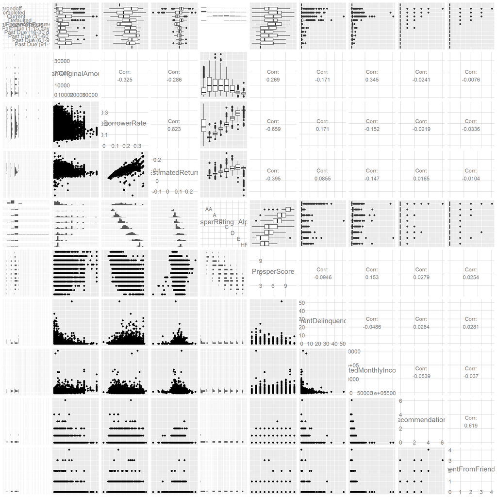

This plot brings a nice overview over the relationships among the selected variables. By providing scatterplots, histograms, box plots and correlation coeficients, this matrix starts to give some sense over the data behavior. For instance, if we take the variables *BorrowerRate* and  
*EstimatedReturn*, we can see that they are positively correlated by looking to the *coeficient* and to the *scatterplot*.

With that in mind, let’s take a closer look over each of these variables.

```r
#
# ...Removing loan registries that originated before July 2009...
# ...This can be done by subsetting our dataset...
# ...The 'columns_list' defined earlier will be used from now on...
#

ld <- subset(loanData
       ,as.Date(LoanOriginationDate) >= as.Date('2009-07-01')
       ,select = columns_list
       )

ld$ProsperScore <- factor(ld$ProsperScore)

str(ld)
```

```
## 'data.frame':    84984 obs. of  10 variables:
##  $ LoanStatus                : Ord.factor w/ 12 levels "Cancelled"<"Chargedoff"<..: 4 4 4 4 4 4 4 4 4 7 ...
##  $ LoanOriginalAmount        : int  10000 10000 15000 15000 3000 10000 10000 10000 13500 4000 ...
##  $ BorrowerRate              : num  0.092 0.0974 0.2085 0.1314 0.2712 ...
##  $ EstimatedReturn           : num  0.0547 0.06 0.0907 0.0708 0.1107 ...
##  $ ProsperRating..Alpha.     : Ord.factor w/ 8 levels ""<"AA"<"A"<"B"<..: 3 3 6 4 7 5 2 2 5 4 ...
##  $ ProsperScore              : Factor w/ 11 levels "1","2","3","4",..: 7 9 4 10 2 4 9 11 7 4 ...
##  $ CurrentDelinquencies      : int  0 4 0 0 0 0 0 0 1 0 ...
##  $ StatedMonthlyIncome       : num  6125 2875 9583 8333 2083 ...
##  $ Recommendations           : int  0 0 0 0 0 0 0 0 0 0 ...
##  $ InvestmentFromFriendsCount: int  0 0 0 0 0 0 0 0 0 0 ...
```

## Univariate Plots Section

#### Analysing how the **Loan Status** variable is distributed

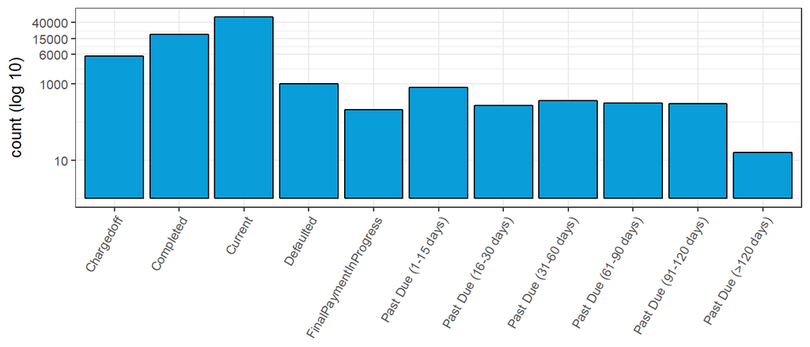

```
##
##              Cancelled             Chargedoff              Completed
##                      0                   5342                  19786
##                Current              Defaulted FinalPaymentInProgress
##                  56576                   1008                    205
##   Past Due (1-15 days)  Past Due (16-30 days)  Past Due (31-60 days)
##                    806                    265                    363
##  Past Due (61-90 days) Past Due (91-120 days)   Past Due (>120 days)
##                    313                    304                     16
```

By taking a look at the plot and the table above, we can easily see that the **Current** status is the highest one. Also, we can realize that there is not many loans with delay on payments. However, the number of **Chargeoffs** is the third highest, which means that more than 5,000 borrowers became delinquent and did not pay their debts in due time.

Another interesting thing to keep in mind is that in the analysed period there are no loans that have been **Canceled**.

Let’s keep going.

#### Analysing how the Loan Amount variable is distributed

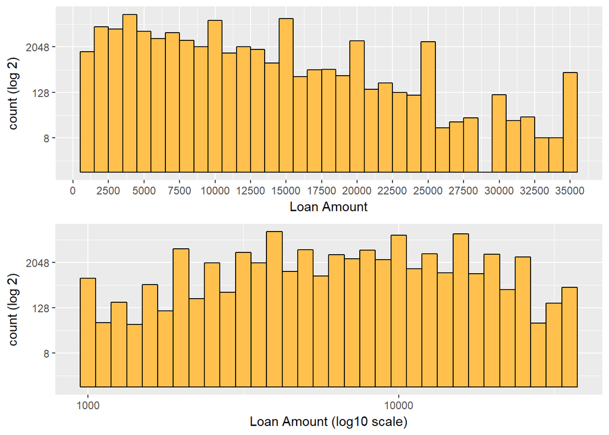

```
##    Min. 1st Qu.  Median    Mean 3rd Qu.    Max.
##    1000    4000    7500    9076   13500   35000
```

The Loan values range from $1,000 to $35,000 and we have some common values in this interval, something around $4,000, $10,000 and $15,000.

#### Analysing how the Listings are distributed across the **Risk Ratings**

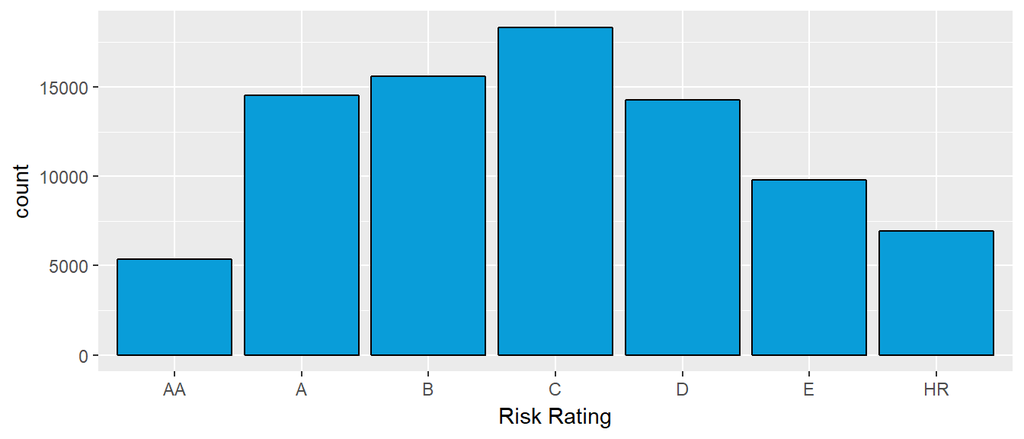

```
##
##    AA     A     B     C     D     E    HR
##  5372 14551 15581 18345 14274  9795  6935
```

The **Risk Ratings** defined by **Prosper** represent an estimated average annualized loss rate range. With **AA** being the lowest risk and **HR** the highest risk associated.

In this histogram we can see a **Normal Distribution** where the upper and lower bounds present a small frequency, and we have higher frequencies in the middle.

Besides that, we see that we have **131** registries without a defined Rating (i.e. blank).

#### Analysing how the **Estimated Return** is distributed

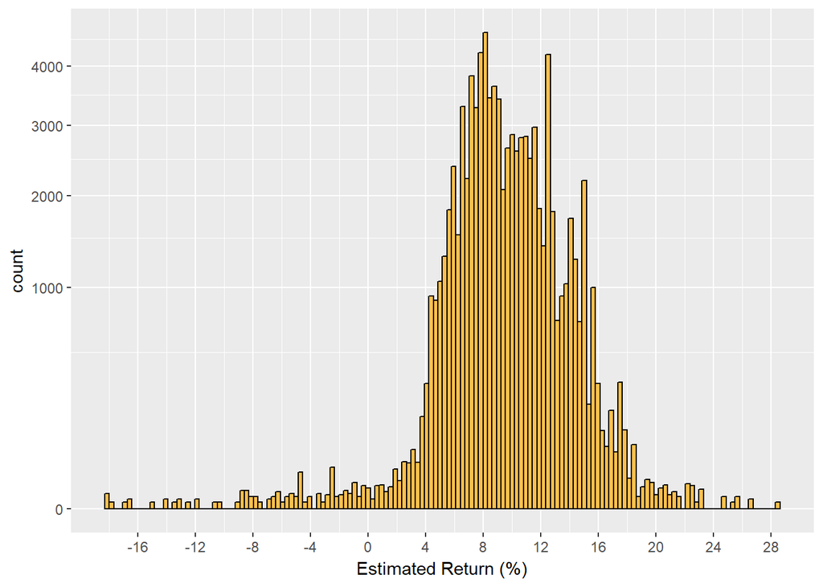

```
##     Min.  1st Qu.   Median     Mean  3rd Qu.     Max.     NA's
## -0.18270  0.07408  0.09170  0.09607  0.11660  0.28370      131
```

The **Estimated Return** is Bimodal, and it ranges from -18.3% to 28.4%.

This scenario is probably related to the risk associated.

If we look to the **Estimated Return** distribution according to the **Risk** associated, what we will find?

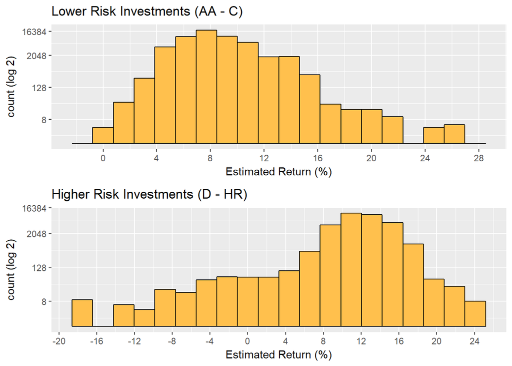

As we can see, in lower levels, a **Estimated Return** between 4% and 12% are more usual, and we have a Normal Distribution of the data.

On the other hand, for higher levels, a **Estimated Return** between 8% and 18% occurs more frequently, and here we can see a Left Skewed Distribution.

However, the **Higher Risk** investments presents **negative** returns, whereas the **Lower Risk** almost do not present this kind of situation.

Later on, we can explore this Estimated Return behaviour a bit deeper.

#### Borrower rate distribution

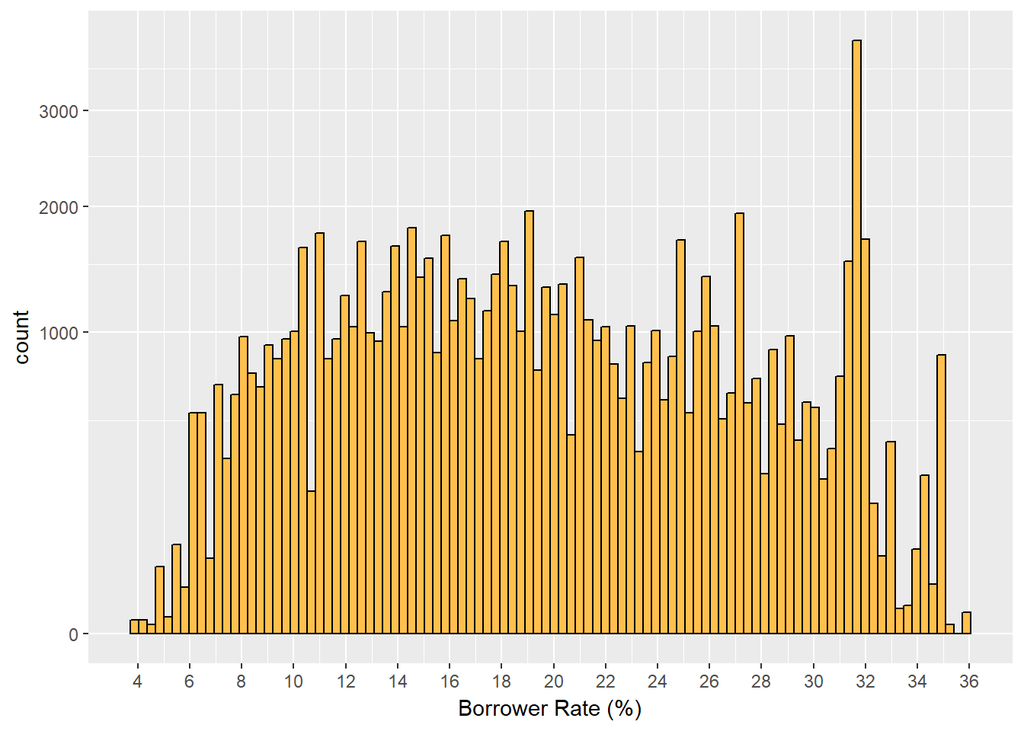

```
##    Min. 1st Qu.  Median    Mean 3rd Qu.    Max.
##  0.0400  0.1359  0.1875  0.1960  0.2574  0.3600
```

The Borrower’s Rate range from 4% to 36% with a mean of 19.6%.

The rate of something close to 32% is the most common one. It is interesting since it is a pretty high interest rate.

One thing that comes to my mind is how is this related to the risk? Does do people who offer higher rates usually presents a higher risk?

#### Analysing how the **Prosper Score** is distributed

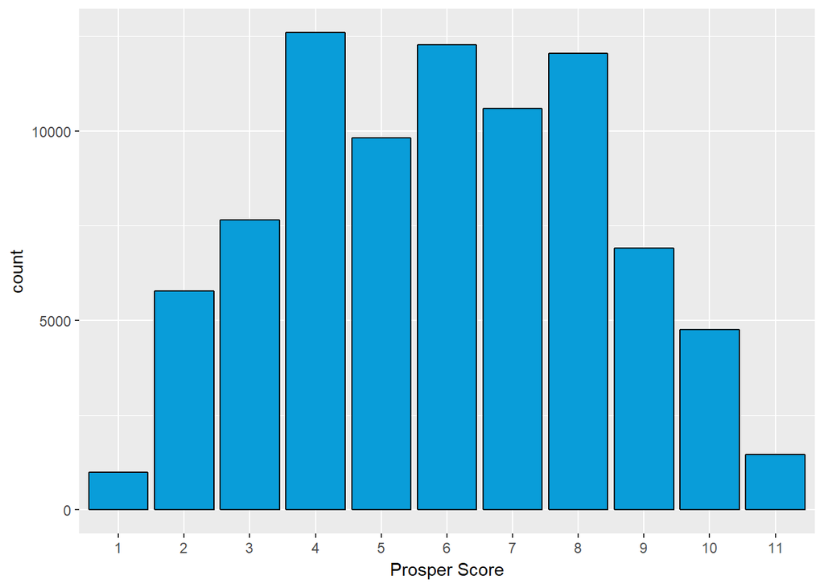

```
##
##     1     2     3     4     5     6     7     8     9    10    11
##   992  5766  7642 12595  9813 12278 10597 12053  6911  4750  1456
```

The **Prosper Score** assess borrower’s profile to provide another tool to the investors when selecting a listing.

In this case, **1** represents the worst score and consequently has a higher risk associated to it, and **11** represents the best score.

#### Monthly Income of Borrowers

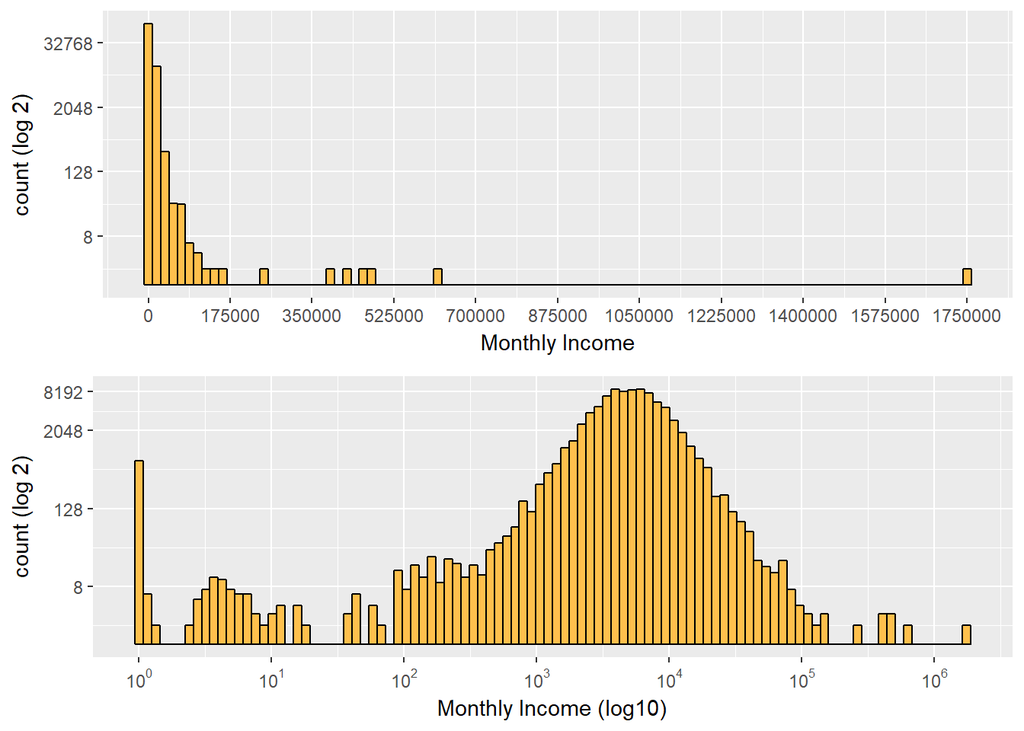

```
##    Min. 1st Qu.  Median    Mean 3rd Qu.    Max.
##       0    3433    5000    5930    7083 1750003
```

```
##   95%
## 12500
```

With the information above, we can see that most of the incomes (**95% of them**) are below **$12,500**.

The interesting thing to notice here is that the values are between **$0 and $1,750,003**.

So we definetly have some outliers in our dataset.

#### Current Delinquencies

Instead of caring about how many delinquencies a borrower had, I will create a variable that tells us whether a borrower has been delinquent.

```r
ld$HasBeenDelinquent <- ifelse(ld$CurrentDelinquencies > 0, 1, 0)
```

#### Recommendations & Investment From Friends Count

```
## [1] "« Recommendations Table »"
```

```
##
##     0     1     2     3     4     5     9    18    19
## 83758  1039   157    22     2     2     1     2     1
```

```
## 98%
##   0
```

```
## [1] "« Investment From Friends Count Table »"
```

```
##
##     0     1     2     3     4     5     6     9
## 84393   528    47     9     2     2     2     1
```

```
## 99%
##   0
```

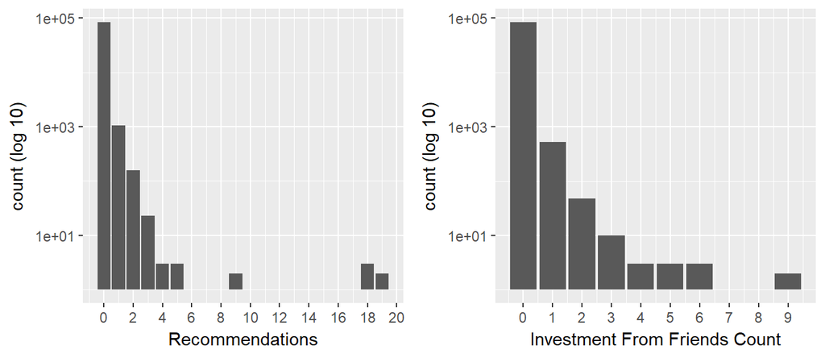

If we take a look at these two variables, we can see that the number of borrowers that have some occurence associated is too low.

For **Recommendations**, 98% of the data are composed by 0’s, and for **InvestmentFromFriendsCount**, 99% of the data are composed by 0’s.

For this reason, these two variables won’t be considered from now on.

## Univariate Plots - Review

In this section we had a dataset overview.

We have **113,937** registers with **81** variables each.

From those variables, some of them seem to be more important for the whole analysis such as **Risk Rating**, **Estimated Return** and **Prosper Score**.

The other features such as **Borrower Rate**, **Monthly Income**, **Loan Status** and **Current Delinquencies** maybe will provide interesting insights when analysed with other variables and will support our investigation.

A new variable (*HasBeenDelinquent*) was created so we could have two groups in our dataset to be compared.

Lastly but not least, one of the views that caught my attention was the **Estimated Return** distribution that presents some peaks that would be interesting to understand where they come from, what is causing them.

Well, let’s see what else we can extract from our dataset.

## Bivariate Plots Section

Now that we have some views over the selected variables we can try to understand how these data is related to each other.

#### Loan Amount x Risk

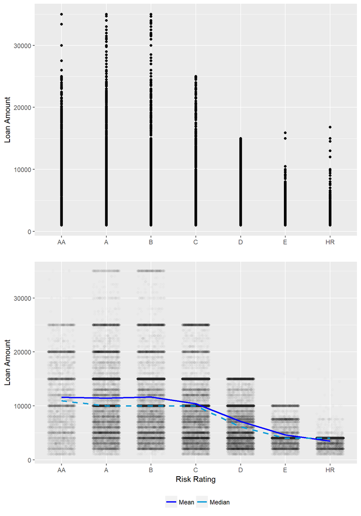

| Risk Rating | Mean Loan Amount | Median Loan Amount | n |
| --- | --- | --- | --- |
| AA | 11583.539 | 10940 | 5372 |
| A | 11459.886 | 10000 | 14551 |
| B | 11622.355 | 10000 | 15581 |
| C | 10391.940 | 10000 | 18345 |
| D | 7083.439 | 6100 | 14274 |
| E | 4586.405 | 4000 | 9795 |
| HR | 3463.114 | 4000 | 6935 |

For our first bivariate plot we have the **Loan Amount** and the **Risk Rating** variables.

The first plot could give us a sensation that most of the high loans were related to lower risk ratings, but if we try to see how these points were concentrated we will see that things change a little bit.

Taking the second plot as base, we can see that the diffence of loan amount among the ratings exists and it grows as the risk raises. However, this is not as significant as it seemed in the first plot.

Let’s make this visualization even better.

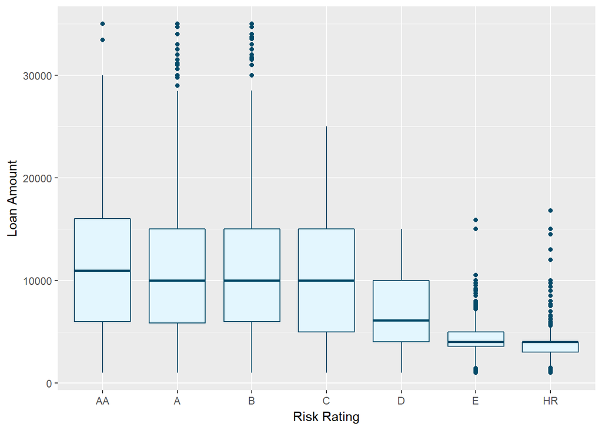

Now it is easier to understand how the **Loans Amount** vary among the **Risk Ratings**.

As the risk gets higher the loan amount decreases.

#### Borrower Rate x Estimated Return

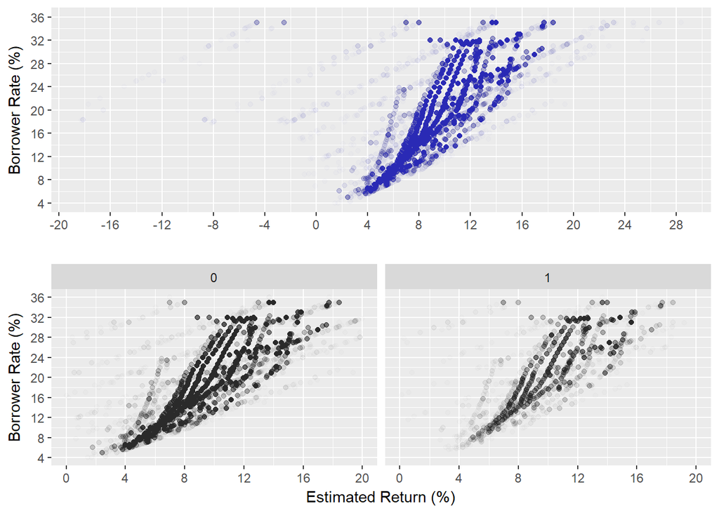

```
##
##  Pearson's product-moment correlation
##
## data:  ld$EstimatedReturn and ld$BorrowerRate
## t = 413.73, df = 84851, p-value < 2.2e-16
## alternative hypothesis: true correlation is not equal to 0
## 95 percent confidence interval:
##  0.8154276 0.8198876
## sample estimates:
##       cor
## 0.8176699
```

Here we can see that these two variables are **positively correlated**.

I tried to verify if the *Delinquents* could influence some how in the data, but the results showed me that Delinquents (1) and Non-delinquents (0) are distributed in the same way.

#### Monthly Income x Prosper Score

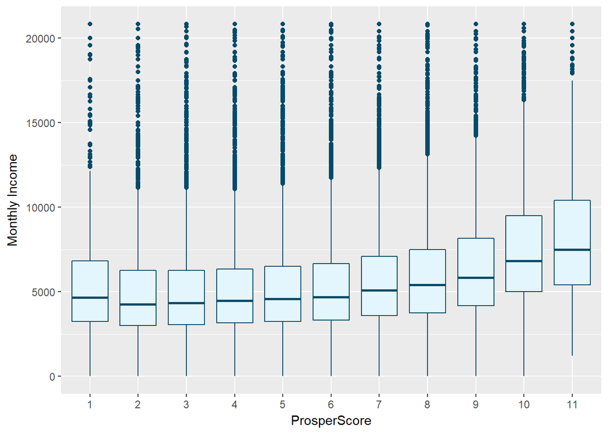

It is possible to notice that as the **Prosper Score** raises the **Income** tends to grow as well.

Therefore, perhaps borrowers with a higher monthly income tend to be more reliable and it makes some sense since those people has a higher chance of being able paying their debts.

#### Estimated Return x Risk Rating - For Chargedoffs

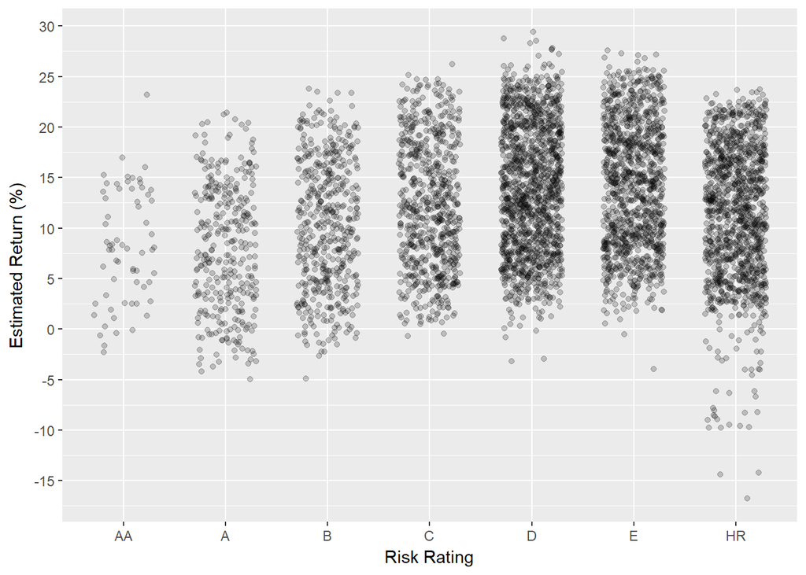

```
## ProsperRating..Alpha.
##   AA    A    B    C    D    E   HR
##   63  326  500  706 1395 1131 1215
```

The loans that has a *Chargedoff* status are highly concentrated for higher risk investments.

Since I added some noise to the data to analyse how the points were concentrated, the Estimated Return rate loses its meaning.

So let’s create a box plot to see the correct behaviour of the Estimated Return when related to Risk Ratings, and this time considering all possible status.

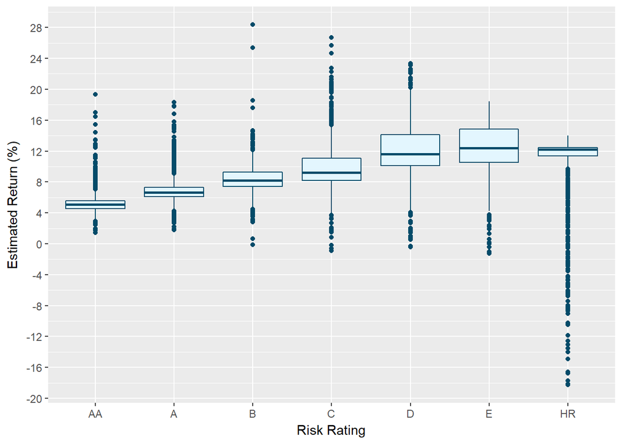

This view is very interesting since it provide us a nice overview over the Risk levels when it comes to the estimated yield.

Besides that, for this data history, **D and E** appear to present better results when compared to the other levels. The IQR (Interquartile Range) of these two levels are more spread than the others and go from 10% to 15%.

## Bivariate Plots - Review

The plots developed in this section provided some sense over the relationship that exists between the selected variables.

Some of them presents some interesting results such as the **Estimated Return x Risk Rating**, while others do not add any insights.

The **Risk Rating** variable and the **Prosper Score** appear to present the same idea over the listings since both of them are related to the risk associated to each Loan.

We could also perceive that a relationship between the **Monthly Income** and the **Prosper Score** occurs, at least in the dataset that we have available.

Well, let’s add more variables to our charts.

## Multivariate Plots Section

We can go deeper in the analysis and give more sense to our data if we look how other variables behave by adding then to one of the bivariate plots created in the last section or just by creating new plots with more than 2 variables.

Let’s try it out.

#### Monthly Income x Estimated Return colored by Risk Rating

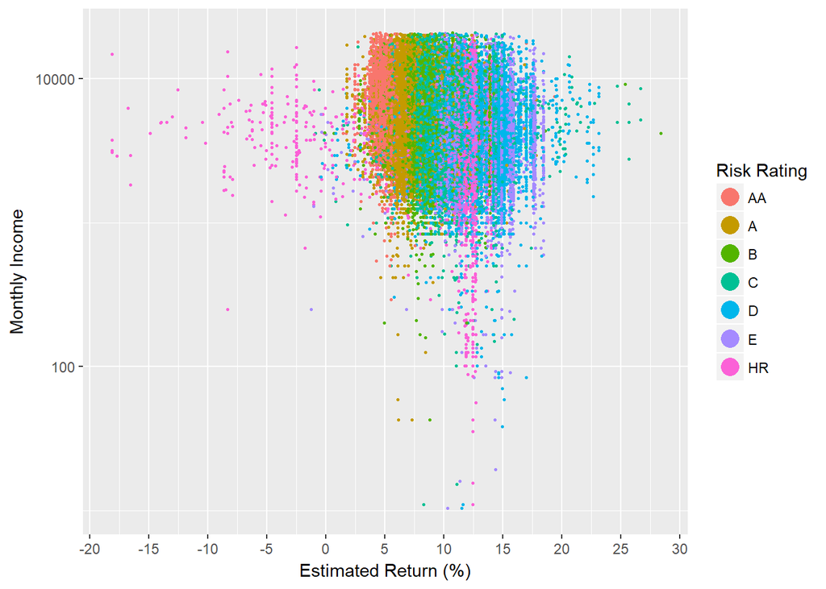

In this first plot, I intended to verify if there was a relationship between **Monthly Income** and **Estimated Return**, but there is not.

Also, there is not a clear relationship between **Monthly Income** and **Risk Rating**.

#### Estimated Return x Borrower Rate colored by Risk Rating

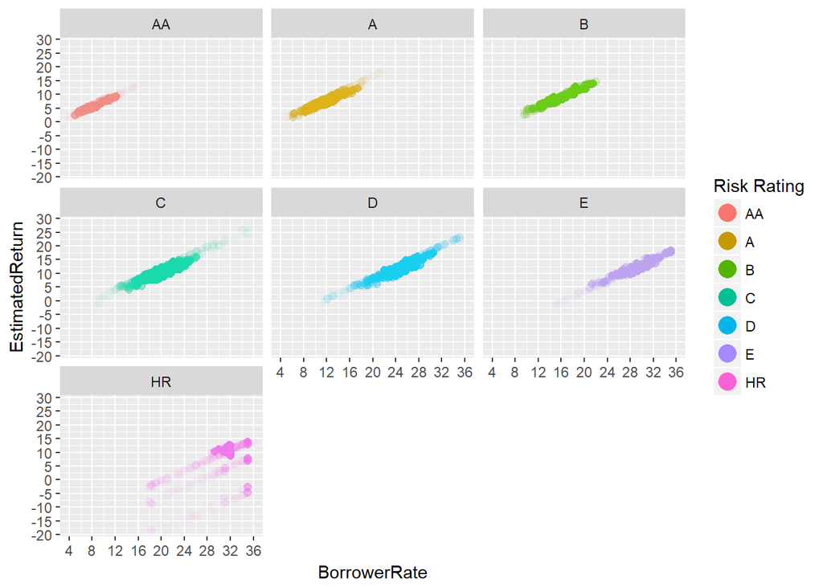

This plot presents a more interesting view over our dataset.

Here we can see that as the interest rate of the borrower raises, the Estimated Return and the Risk Rating also raises.

#### Loan Amount x Estimated Return colored by Risk Rating

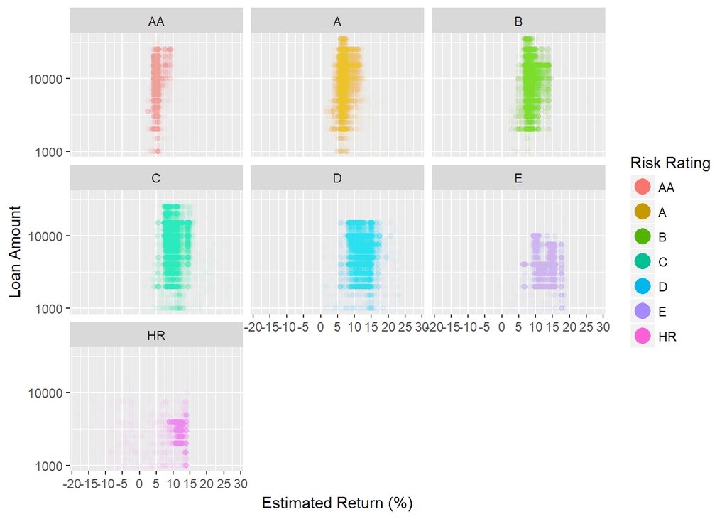

The **Loan Amount** does not have any impact over the behaviour of the other two variables.

#### Estimated Return x ProsperScore colored by Risk Rating

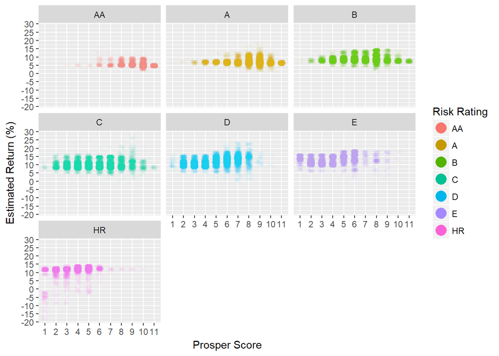

This plot provided interesting information since it showed a comparison between the two Prosper’s evaluators.

At first, I thought they were going to present a similar behaviour to the **Estimated Return** values. That is as the return raise, **Prosper Score** and **Risk Rating** would have a proportional increase in its risk.

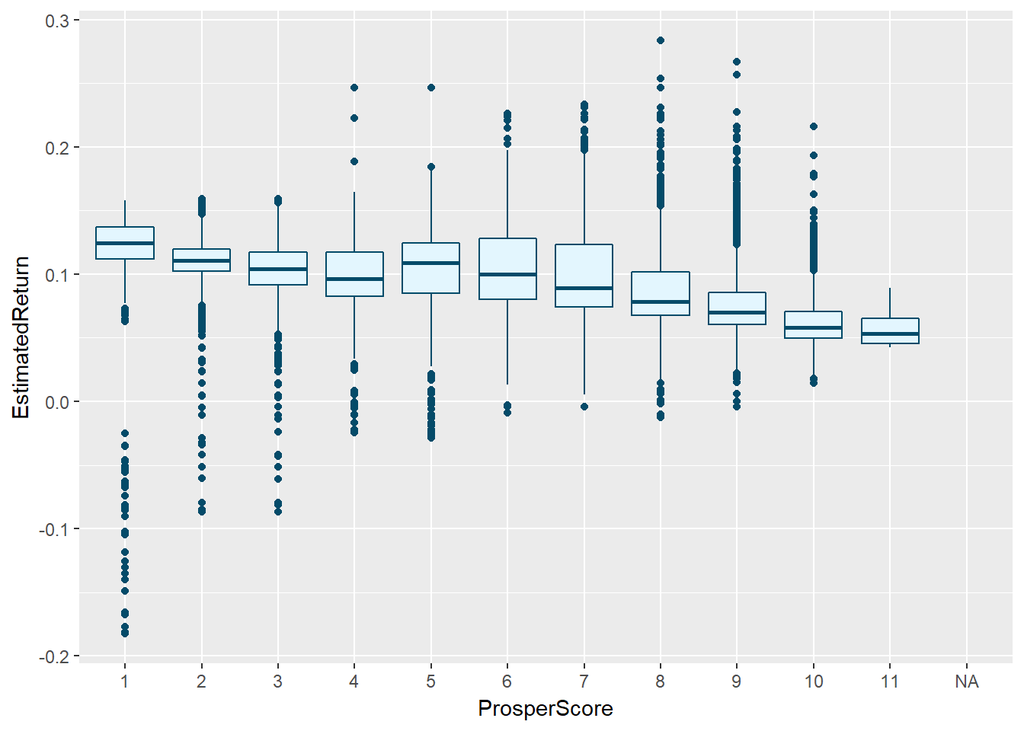

As higher the risk is (closer to 1), the higher the **Estimated Return** gets.

## Multivariate Plots - Review

One of the main conclusions that I can take from this section is that the “support variables” did not bring any valuable insights such as the **Monthly Income** or the **Loan Status**.

The main features - **Estimated Return**, **Prosper Score** and **Risk Rating** - were the ones that presented more interesting views over the dataset and those would probably be the variables that I would keep analysing for further results and conclusions.

## Final Plots and Summary

### Plot One

#### **Estimated Return** distribution

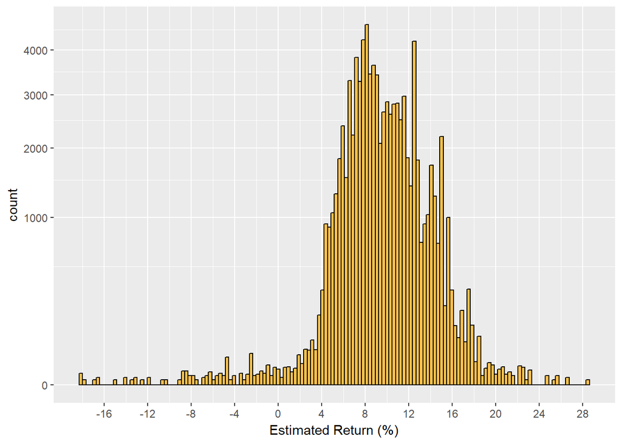

```
##     Min.  1st Qu.   Median     Mean  3rd Qu.     Max.     NA's
## -0.18270  0.07408  0.09170  0.09607  0.11660  0.28370      131
```

### Description One

This first plots provides a view over the distribution of the **Estimated Return** variable, as mentioned before it has **two peaks** and their are related to the risk associated.

Besides that, we can also see that some listings have a **negative returns**.

We can also easily notice where the most common values lay.

### Plot Two

#### Estimated Return x Risk Rating

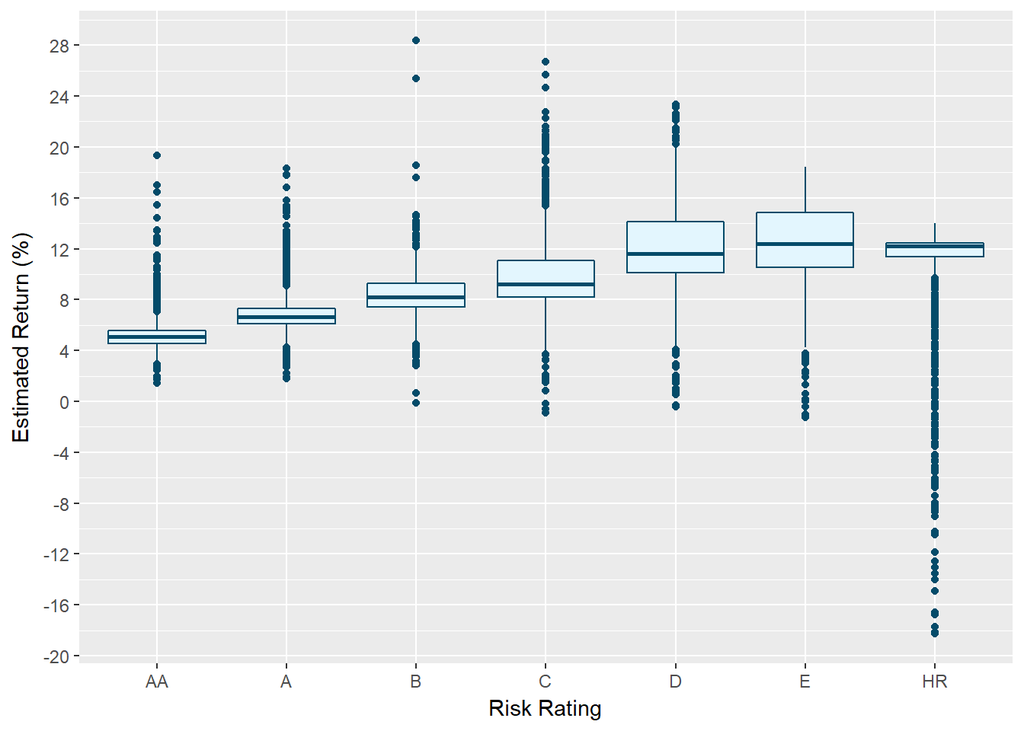

### Description Two

Reiterating what I said before, this plot clarifies how these two variables are related to each other.

From here, we can say that the levels **D and E** presents better results.

### Plot Three

#### Estimated Return x ProsperScore colored by Risk Rating

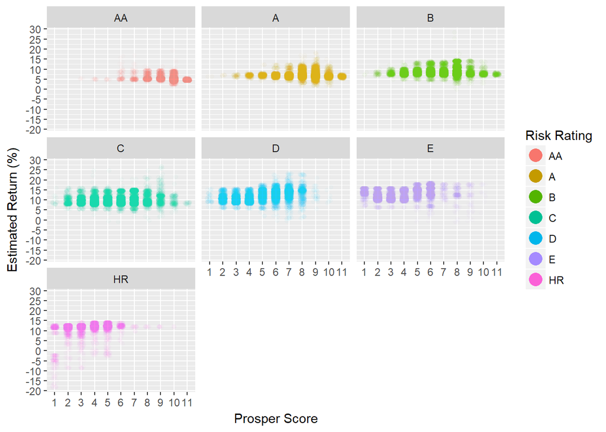

### Description Three

Since this plots puts together the two Prosper’s evaluators and the main feature, the **Estimated Return**, it gives information on how those two can be used together to achieve better results when investing in a listing.

## Reflection

This data set presents a lot of informations with lots of variables what makes it difficult to comprehend what can provide nice results.

Selecting those variables is not easy. After studying about the dataset and about **Prosper** things start to become a bit clearer, even so lacks expertise over the main subject to provide more valuable insights.

However, it was possible to create some interesting plots that show that some features behave in an unexpected way.

After developing this analysis, I would probably be more confortable to invest in listings that has some risk associated because they would provide me better results and even so I would not lose money easily.

Of course I could go further by applying more analysis over data. At first, I could try applying [PCA](https://www.r-bloggers.com/computing-and-visualizing-pca-in-r/) to aid me in the process of variables selection.

## References

- Udacity - https://classroom.udacity.com/
- R Markdown - http://rmarkdown.rstudio.com/authoring_basics.html
- Prosper - https://www.prosper.com
- Stackoverflow - https://stackoverflow.com/
- ggplot2 - http://ggplot2.tidyverse.org
- R Documentation - https://www.rdocumentation.org/

## Appendix

| Variable | Description |
| --- | --- |
| ListingKey | Unique key for each listing, same value as the ‘key’ used in the listing object in the API. |
| ListingNumber | The number that uniquely identifies the listing to the public as displayed on the website. |
| ListingCreationDate | The date the listing was created. |
| CreditGrade | The Credit rating that was assigned at the time the listing went live. Applicable for listings pre-2009 period and will only be populated for those listings. |
| Term | The length of the loan expressed in months. |
| LoanStatus | The current status of the loan: Cancelled, Chargedoff, Completed, Current, Defaulted, FinalPaymentInProgress, PastDue. The PastDue status will be accompanied by a delinquency bucket. |
| ClosedDate | Closed date is applicable for Cancelled, Completed, Chargedoff and Defaulted loan statuses. |
| BorrowerAPR | The Borrower’s Annual Percentage Rate (APR) for the loan. |
| BorrowerRate | The Borrower’s interest rate for this loan. |
| LenderYield | The Lender yield on the loan. Lender yield is equal to the interest rate on the loan less the servicing fee. |
| EstimatedEffectiveYield | Effective yield is equal to the borrower interest rate (i) minus the servicing fee rate, (ii) minus estimated uncollected interest on charge-offs, (iii) plus estimated collected late fees. Applicable … |
| EstimatedLoss | Estimated loss is the estimated principal loss on charge-offs. Applicable for loans originated after July 2009. |
| EstimatedReturn | The estimated return assigned to the listing at the time it was created. Estimated return is the difference between the Estimated Effective Yield and the Estimated Loss Rate. Applicable for loans orig… |
| ProsperRating (numeric) | The Prosper Rating assigned at the time the listing was created: 0 - N/A, 1 - HR, 2 - E, 3 - D, 4 - C, 5 - B, 6 - A, 7 - AA. Applicable for loans originated after July 2009. |
| ProsperRating (Alpha) | The Prosper Rating assigned at the time the listing was created between AA - HR. Applicable for loans originated after July 2009. |
| ProsperScore | A custom risk score built using historical Prosper data. The score ranges from 1-10, with 10 being the best, or lowest risk score. Applicable for loans originated after July 2009. |
| ListingCategory | The category of the listing that the borrower selected when posting their listing: 0 - Not Available, 1 - Debt Consolidation, 2 - Home Improvement, 3 - Business, 4 - Personal Loan, 5 - Student Use, 6 … |
| BorrowerState | The two letter abbreviation of the state of the address of the borrower at the time the Listing was created. |
| Occupation | The Occupation selected by the Borrower at the time they created the listing. |
| EmploymentStatus | The employment status of the borrower at the time they posted the listing. |
| EmploymentStatusDuration | The length in months of the employment status at the time the listing was created. |
| IsBorrowerHomeowner | A Borrower will be classified as a homowner if they have a mortgage on their credit profile or provide documentation confirming they are a homeowner. |
| CurrentlyInGroup | Specifies whether or not the Borrower was in a group at the time the listing was created. |
| GroupKey | The Key of the group in which the Borrower is a member of. Value will be null if the borrower does not have a group affiliation. |
| DateCreditPulled | The date the credit profile was pulled. |
| CreditScoreRangeLower | The lower value representing the range of the borrower’s credit score as provided by a consumer credit rating agency. |
| CreditScoreRangeUpper | The upper value representing the range of the borrower’s credit score as provided by a consumer credit rating agency. |
| FirstRecordedCreditLine | The date the first credit line was opened. |
| CurrentCreditLines | Number of current credit lines at the time the credit profile was pulled. |
| OpenCreditLines | Number of open credit lines at the time the credit profile was pulled. |

[output cut: 51 more lines]